# TDI Finalist Interview - diving into the H-1B visa

### What is the H-1B visa?

The US H-1B visa is a non-immigrant visa that allows US companies to employ graduate level workers in specialty occupations that require theoretical or technical expertise in specialized fields such as IT, finance, accounting, architecture, engineering, science, medicine, etc.

## Preliminary EDA and Machine Learning Model

In this notebook, I will expand on the themes I proposed during the semi-final 'challenge' round. In a separate notebook, I scraped all job titles with more than 1,000 entries (307 total job titles) from the website https://h1bdata.info.

During the semi-final challenge, I looked at salary trends for Data Scientists and top states were the most H1-B visas were granted to data scientists. During this data exploration, I will:

- Look at more general geographical trends for all top job positions
- Check salary trends for popular tech jobs
- Compare granted vs denied applications
- Compare typical wait periods for visa applications for jobs with most entries
- Check tech industry job trends (e.g. are particular positions trending lower/higher during the past 5 years?)

### Import libraries

```python
import pandas as pd
import matplotlib.pyplot as plt
import matplotlib.ticker as ticker
import numpy as np
import string as st
import seaborn as sns
import os
```

```python
%matplotlib inline
```

## Load in previously scraped data

Note: if anyone is interested in playing with this data, I can either provide my scraping code or upload the compiled CSV to a shared cloud folder.  
Please email me at pablo.vega.behar@gmail.com if interested.

```python
CSV_file = os.path.join(os.getcwd(),"CSV-for-ML-Model","Dataset-for-ML-Model.csv")
frame = pd.DataFrame.from_csv(CSV_file, encoding = "ISO-8859-1")
```

```python
#frame.head()
```

### Extract features 'city' and 'state' from 'location'

```python
# Note: this function requires a cleaned up 'location' column with no NaN or empty strings
def get_city_state(df):
    df["state"] = df["location"].str.split().str[-1]
    df["location"].apply(lambda x: "".join(x.split()[1:]))
    df["location"] = df["location"].apply(lambda x: x.split(" "))
    df["city"] = df["location"].str[:-1].apply(lambda x: " ".join(x))

    df = df[['employer', 'job title', 'base salary', 'submit date',
       'start date', 'case status', 'submit year', 'submit month', 'state', 'city']]

    return df
```

```python
frame = get_city_state(frame)
```

## Start exploratory data analysis

Let's find the top 20 jobs that have employed the most H1-B recipients to analyze them

```python
top_20_jobs = frame.groupby('job title')['job title'].aggregate(
    {'Entries in data set':'count'}).sort_values(by='Entries in data set',ascending=False)[:20]
```

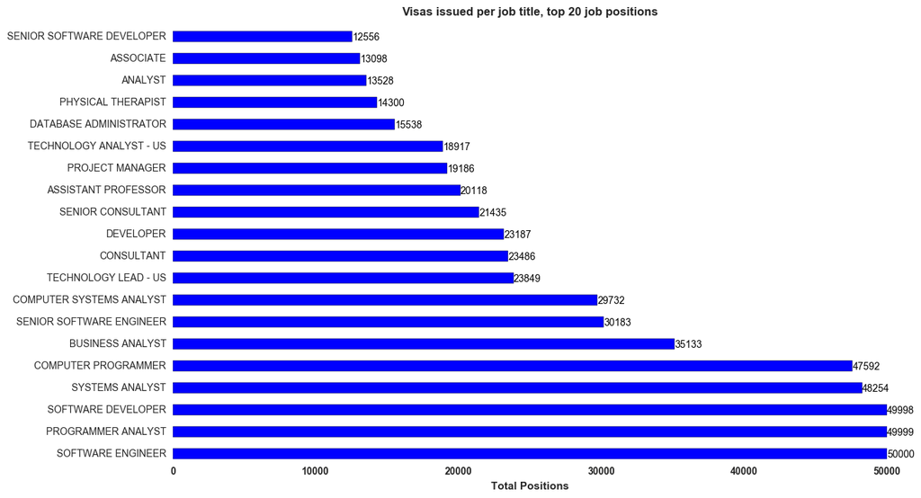

```python
pos = np.arange(len(top_20_jobs['Entries in data set']))
width = 0.5

fig1, ax1 = plt.subplots(figsize=(13,8))
rect1 = ax1.barh(pos, top_20_jobs['Entries in data set'], width, color='Blue', label = 'Visas issued')

ax1.set_xlabel('Total Positions',fontweight='bold')
ax1.set_title('Visas issued per job title, top 20 job positions',fontweight='bold')
ax1.set_yticks(pos+width/2)
ax1.set_axis_bgcolor('white')
ax1.set_yticklabels(tuple(top_20_jobs.index.get_values()))
plt.xticks(ha='center',fontweight='bold')
for i, v in enumerate(top_20_jobs['Entries in data set']):
    ax1.text(v + 10, i+0.1, str(v), color='black')
```

### Let's investigate salaries!

For now, let's just look at the top 7 positions (by visas issued) plus data scientists (since we love data science):

```python
top_7_job_titles = list(top_20_jobs[0:7].index.values)
top_7_job_titles_plus_data_science = top_7_job_titles
top_7_job_titles_plus_data_science.append('DATA SCIENTIST')
```

```python
def filter_job_titles(df, job_title_list):
    df_return = pd.DataFrame()
    list_ = []
    for title in job_title_list:
        df_tmp = df[df['job title']==title]
        list_.append(df_tmp)

    df_return = pd.concat(list_)
    return df_return
```

```python
df_salary = filter_job_titles(frame,top_7_job_titles_plus_data_science)
```

Create a pivot table below to facilitate plotting:

```python
median_salaries = df_salary.groupby(['submit year','job title'])['base salary'].aggregate('median')
salary_pivot_table = median_salaries.reset_index()
salary_pivot_table = salary_pivot_table.pivot_table('base salary', index = 'submit year', columns = 'job title')
```

I placed the plotting steps into a function so that we can easily and quickly plot different numbers of jobs.

```python
def plot_salaries(df, linestyles,linecolors):
    line_titles = []
    for i in range(df.shape[1]):
        line_titles.append(df.columns[i])

    fig2, ax2 = plt.subplots(figsize=(13,8))

    for i, column in enumerate(df.columns):
        ax2.plot(df[column],linestyle=linestyles[i],color=linecolors[i],linewidth=3)

    ax2.legend(line_titles,loc='upper left',frameon=True)
    ax2.set_title('Median Base Salaries',fontweight='bold')
    ax2.set_axis_bgcolor('white')
    y_formatter = ticker.StrMethodFormatter('${x:,.0f}')
    x_formatter = ticker.FormatStrFormatter('%1.0f')
    ax2.yaxis.set_major_formatter(y_formatter)
    ax2.xaxis.set_major_formatter(x_formatter)
    ax2.grid(b=True,which='major',axis='both',color='k',linestyle='--',linewidth=0.5)
```

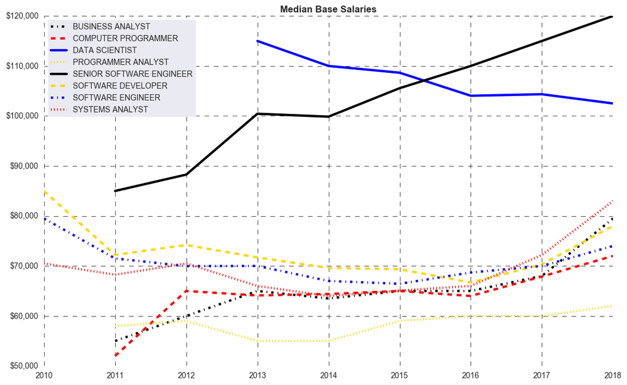

```python
linestyles = ['-.', '--', '-', ':','-', '--', '-.', ':']
linecolors = ['k','r','b','gold','k','gold','b','r']
plot_salaries(salary_pivot_table,linestyles,linecolors)
```

```python
salary_pivot_table2 = salary_pivot_table.drop(['SENIOR SOFTWARE ENGINEER','DATA SCIENTIST'],axis=1)
```

```python
linestyles = ['-.', '--', ':', '--','-.', ':']
linecolors = ['k','r','gold','gold','b','r']
#plot_salaries(salary_pivot_table2,linestyles,linecolors)
```

### This is interesting, but how many people actually hold these jobs PER YEAR?

Note: for this analysis, let's look at only 'CERTIFIED' visas, since presumably 'DENIED', or 'WITHDRAWN' did not actually hold the job position.

```python
#frame['case status'].unique()
```

Let's use the previously filtered df_salary, which had only the 8 positions we want to study in more detail

```python
df_positions = df_salary[df_salary['case status']=='CERTIFIED']
positions_per_year = df_positions.groupby(['submit year','job title'])['job title'].aggregate('count')
positions_pivot_table = positions_per_year.unstack(level=-1)
```

```python
#positions_pivot_table
```

```
''
```

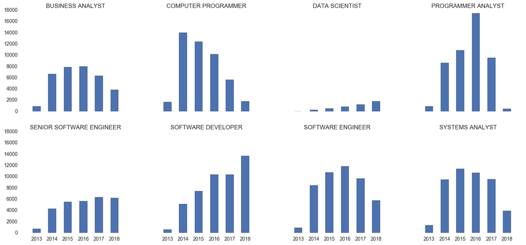

```python
f, ((sax1, sax2, sax3, sax4), (sax5, sax6, sax7, sax8)) = plt.subplots(2, 4, sharex='col', sharey='row',figsize=(18,8))

index = np.arange(positions_pivot_table.shape[0])
width = 0.5

sax1.bar(index-width/2, positions_pivot_table[positions_pivot_table.columns[0]],width)
sax1.set_title(positions_pivot_table.columns[0])
sax1.set_axis_bgcolor('white')
sax2.bar(index-width/2, positions_pivot_table[positions_pivot_table.columns[1]],width)
sax2.set_title(positions_pivot_table.columns[1])
sax2.set_axis_bgcolor('white')
sax3.bar(index-width/2, positions_pivot_table[positions_pivot_table.columns[2]],width)
sax3.set_title(positions_pivot_table.columns[2])
sax3.set_axis_bgcolor('white')
sax4.bar(index-width/2, positions_pivot_table[positions_pivot_table.columns[3]],width)
sax4.set_title(positions_pivot_table.columns[3])
sax4.set_axis_bgcolor('white')
sax5.bar(index-width/2, positions_pivot_table[positions_pivot_table.columns[4]],width)
sax5.set_title(positions_pivot_table.columns[4])
sax5.set_ylim(top=18000)
sax5.set_axis_bgcolor('white')
sax6.bar(index-width/2, positions_pivot_table[positions_pivot_table.columns[5]],width)
sax6.set_title(positions_pivot_table.columns[5])
sax6.set_axis_bgcolor('white')
sax7.bar(index-width/2, positions_pivot_table[positions_pivot_table.columns[6]],width)
sax7.set_title(positions_pivot_table.columns[6])
sax7.set_axis_bgcolor('white')
sax8.bar(index-width/2, positions_pivot_table[positions_pivot_table.columns[7]],width)
sax8.set_title(positions_pivot_table.columns[7])
sax8.set_axis_bgcolor('white')
sax1.set_xticklabels(tuple(positions_pivot_table.index.get_values()))
sax1.set_xticks(index)
sax2.set_xticklabels(tuple(positions_pivot_table.index.get_values()))
sax2.set_xticks(index)
sax3.set_xticklabels(tuple(positions_pivot_table.index.get_values()))
sax3.set_xticks(index)
sax4.set_xticklabels(tuple(positions_pivot_table.index.get_values()))
sax4.set_xticks(index)
''''''
```

**NOTE:** The dropoff in computer programmer and systems analyst positions needs further investigation. Is it real or is it due to the cutoff during web scraping?

```python
#positions_pivot_table
```

#### Speaking of visas that were NOT certified, what percentage are not?

```python
case_status = df_salary.groupby(['job title','case status'])['case status'].count().unstack(level=-1)
case_status['NOT CERTIFIED']=case_status['DENIED']+case_status['WITHDRAWN']
```

```python
def visas_not_certified(df):
    index = np.arange(len(df['NOT CERTIFIED']))
    df['% NOT CERTIFIED'] = round(df['NOT CERTIFIED']/(df['CERTIFIED']+df['NOT CERTIFIED'])*100,2)

    width=0.4
    fig, ax = plt.subplots(figsize = (8,6))
    ax.bar(index-2*width/3, df['% NOT CERTIFIED'], width)

    df['avg not cert'] = (df['% NOT CERTIFIED'].mean())
    line = df['avg not cert'].plot(linestyle='--', color='r')

    ax.set_ylabel('Not Certified / Total H-1B applications (%)')
    ax.set_title('Percentage of visas not certified (%)')
    ax.set_xticks(index)
    ax.text(index[0], df['avg not cert'].values[0]+0.1, 'average', color='red', fontweight='bold')
    ax.set_axis_bgcolor('white')
    ax.set_xlim(-0.5,8.5)
    ax.set_xticklabels(tuple(df.index.get_values()),rotation=45, ha='right')
    plt.show()
```

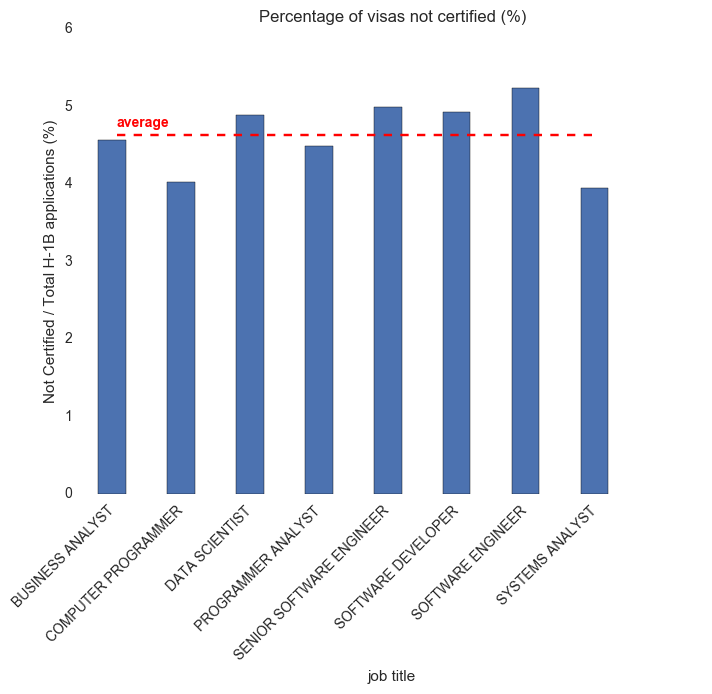

```python
visas_not_certified(case_status)
```

### Let's look at geography!

```python
#df_salary.head()
```

```python
positions_top_states = frame.groupby('state')['employer'].aggregate({'issued': 'count', \
                      'employers': 'nunique'}).sort_values(by = 'issued', ascending = False)[:10]
```

```python
def top_states(df):
    index = np.arange(len(df['issued']))
    width = 0.4

    fig, ax = plt.subplots(figsize=(8,8))

    rect1 = ax.bar(index-3*width/2, df['issued'], width, color='Blue', label = 'Visas issued')
    rect2 = ax.bar(index-width/2, df['employers'], width, color='Red', label = '# of employers sponsoring visas')

    ax.set_ylabel('Visas issued (blue) and employers issuing (red) per state')
    ax.set_title('Top 10 states issuing H-1B visas, by visas issued')
    ax.set_xticks(index-width/2)
    ax.set_xticklabels(tuple(df.index.get_values()))
    ax.set_axis_bgcolor('white')
    ax.legend()

    if df['issued'].max() > 10000:
        for i, v in enumerate(df['issued']):
            if v < 100000:
                ax.text(index[i]-2.5*width/2, v+14000, str(v), color='blue',rotation=90, fontweight='bold')
            else:
                ax.text(index[i]-2.5*width/2, v+16000, str(v), color='blue',rotation=90, fontweight='bold')

        for i, v in enumerate(df['employers']):
            if v < 10000:
                ax.text(index[i]-width/3.5, v+11000, str(v), color='red',rotation=90, fontweight='bold')
            else:
                ax.text(index[i]-width/3.5, v+14000, str(v), color='red',rotation=90, fontweight='bold')

    if df['issued'].max() < 10000:
        for i, v in enumerate(df['issued']):
            if v < 1000:
                ax.text(index[i]-2.5*width/2, v+85, str(v), color='blue',rotation=90, fontweight='bold')
            else:
                ax.text(index[i]-2.5*width/2, v+120, str(v), color='blue',rotation=90, fontweight='bold')

        for i, v in enumerate(df['employers']):
            if v < 100:
                ax.text(index[i]-width/3.5, v+50, str(v), color='red',rotation=90, fontweight='bold')
            else:
                ax.text(index[i]-width/3.5, v+100, str(v), color='red',rotation=90, fontweight='bold')

    plt.show()
```

```
Top states issuing visas, considering all job positions scraped
```

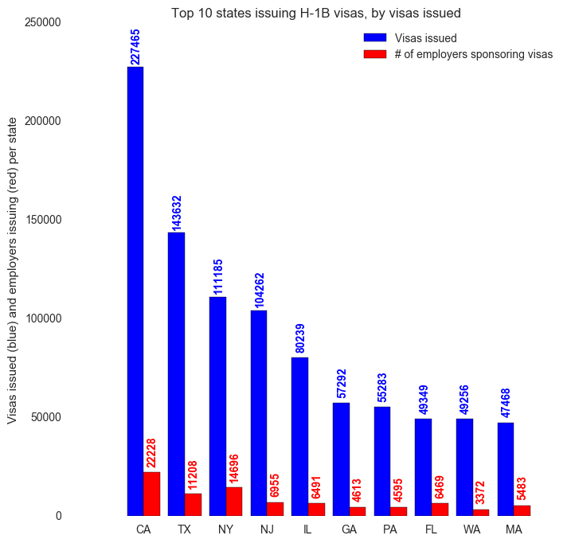

```python
print('Top states issuing visas, considering all job positions scraped')
top_states(positions_top_states)
```

Specifically for data scientists:

```
Top states issuing visas for data scientists
```

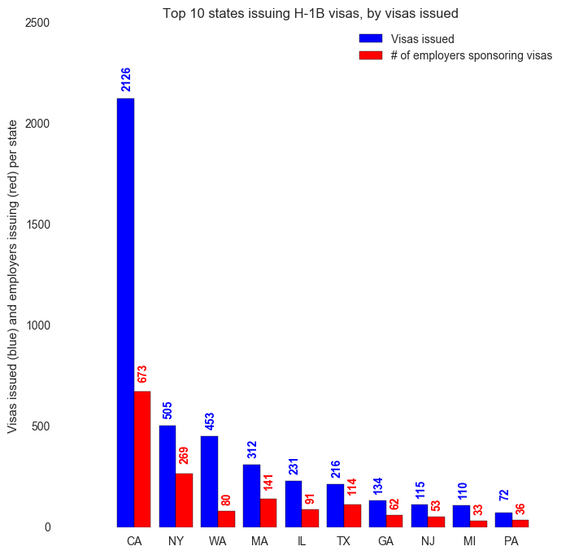

```python
data_scientists_top_states = df_salary[df_salary['job title']=='DATA SCIENTIST'].groupby('state')['employer'].aggregate({'issued': 'count', \
                     'employers': 'nunique'}).sort_values(by = 'issued', ascending = False)[:10]
print('Top states issuing visas for data scientists')
top_states(data_scientists_top_states)
```

Interestingly, the top 10 are almost identical (disregarding their rank), except FL is not in the top 10 for data scientists, and MI is not in the top 10 overall.

```python
state_issue_salary = df_salary[df_salary['job title']=='DATA SCIENTIST'].groupby('state')['base salary'].aggregate({'issued': 'count', \
                                          'average_salary':'mean'}).sort_values(by = 'issued', ascending = False)
state_issue_salary['average_salary'] = round(state_issue_salary['average_salary'],1)
state_issue_salary10 = state_issue_salary[:10]
```

```python
#state_issue_salary10.head()
```

```python
def top_states_with_salary(df):
    #title = df['job title'][0]
    width = 0.4
    index = np.arange(len(df['issued']))

    height_list = [0]
    fig1, ax = plt.subplots(figsize = (20,8))
    rect1 = ax.bar(index-width/2, df['issued'], width, color = 'Blue', label = 'Visas Issued')
    ax2 = ax.twinx()
    line = df['average_salary'].plot(linestyle='-', marker='o', ax = ax2, label = 'Average Salary')

    line.set_ylabel('Salary (USD)')
    ax.set_ylabel('Visas Issued')
    ax.set_title('Data Scientist H-1B Issued Visas & Average Base Salary in Top 15 States (by visas issued)')
    ax.set_xticks(index)
    ax.set_xlim(-0.2,10.2)
    ax.set_axis_bgcolor('white')
    ax2.set_axis_bgcolor('white')
    y_formatter = ticker.StrMethodFormatter('${x:,.0f}')
    ax2.yaxis.set_major_formatter(y_formatter)
    ax2.grid(None)
    ax.set_xticklabels(tuple(df.index.get_values()))
    ax.legend(loc = 'upper center')
    line.legend(loc = 'upper right')

    plt.show()
```

[figure not shown]

```python
top_states_with_salary(state_issue_salary10)
#[0,state_issue_salary10['issued'].values,0]
```

## Set up machine learning model

### Import ML libraries

```python
mingw_path = 'C:\\Program Files\\mingw-w64\\x86_64-7.2.0-posix-seh-rt_v5-rev1\\mingw64\\bin'
os.environ['PATH'] = mingw_path + ';' + os.environ['PATH']

import xgboost as xgb
from sklearn.preprocessing import LabelEncoder
from sklearn.model_selection import train_test_split, GridSearchCV
from sklearn.metrics import explained_variance_score
from sklearn.metrics import r2_score, mean_squared_error

import gc # Note: this is a garbage collector
import warnings
warnings.filterwarnings('ignore')
```

### Split dataset into X/y and train/validation/test sets

```python
X = frame[['employer', 'job title','case status', 'submit year', 'submit month', 'state', 'city']]
y = np.log1p(frame[['base salary']].values)
```

### Label encoding

Multiple label enconding per:  
https://stackoverflow.com/questions/24458645/label-encoding-across-multiple-columns-in-scikit-learn/47100771#47100771

This is an **excellent** solution.  
**Note:** investigate later how to save the default dict to a JSON file so I can 1) load it back later if loading the model (pickle) elsewhere.

```python
from collections import defaultdict
```

```python
d = defaultdict(LabelEncoder)
cols_to_transf=['employer','job title','state','city','case status']
```

#### Create functions (for now) to transform and inverse transform dataframes

Use functions to facilitate multiple dataframe transformations. Look into creating a class that does this later, rather than a series of separate functions.

```python
def fit_and_transform(df,cols_to_transf):
    df_transf = df[cols_to_transf]
    df_non_transf = df.drop(cols_to_transf, axis = 1)

    fit = df_transf.apply(lambda x: d[x.name].fit_transform(x))

    df = pd.concat([fit, df_non_transf], axis=1, join='outer')
    return df
```

```python
def inverse_encoding(df,encoded_cols):
    df_inverse = df[encoded_cols]
    df_non_inv = df.drop(encoded_cols, axis = 1)

    df_inverse = df_inverse.apply(lambda x: d[x.name].inverse_transform(x))
    df = pd.concat([df_inverse, df_non_inv], axis=1, join='outer')

    return df
```

```python
def encode_future_data(df,cols_to_transf):
    df_transf = df[cols_to_transf]
    df_non_transf = df.drop(cols_to_transf, axis = 1)

    fit = df_transf.apply(lambda x: d[x.name].transform(x))

    df = pd.concat([fit, df_non_transf], axis=1, join='outer')
    return df
```

```python
X = fit_and_transform(X, cols_to_transf)
```

```python
test_size = 0.25 # assign proportion of dataset to test set split
X_train, X_test, y_train, y_test = train_test_split(X, y, test_size=test_size)

del X, y; gc.collect()
```

```
38336
```

```python
X_train, X_valid, y_train, y_valid = train_test_split(X_train, y_train, test_size=0.2)
```

Save the column order going into the DMatrix for encoding and predicting future data

```python
future_data_column_order = ['employer', 'job title', 'state', 'city', 'case status', 'submit year', 'submit month']
#future_data_column_order = ['employer', 'job title', 'case status', 'submit year', 'submit month', 'state', 'city']
```

```python
d_train = xgb.DMatrix(X_train, label = y_train)
d_valid = xgb.DMatrix(X_valid, label = y_valid)

del X_train, X_valid; gc.collect()
```

```
9
```

#### Parameters for model

**Note:** In a previous notebook version I used Grid Search to find "best" max_depth (= 5), and min_child_weight (= 2). Not a true best because the training took a long time so I only analyzed 8 combinations of these 2 parameters.

```python
params = {"objective": "reg:linear",
          "learning_rate": 0.1,
          "max_depth": 5,
          "min_child_weight": 2,
          "eval_metric": "rmse",
          "silent": 1,
          "colsample_bytree": 0.7,
          "seed": 24}
```

#### Start training...

```python
watchlist = [(d_train, 'train'), (d_valid, 'valid')]
clf = xgb.train(params, d_train, num_boost_round=10000, evals=watchlist,early_stopping_rounds=20,verbose_eval=200)
```

[output not shown]

#### Save the trained model

```python
import pickle
```

```python
with open("TDI-XGB_model.pkl", "wb") as f:
    pickle.dump(clf, f)
```

**NOTE:** To retrieve the trained model later, change cell below from 'Markdown' to 'Code':

with open("TDI-XGB_model.pkl", "rb") as f: XGB_model = pickle.load(f)

#### Verify model with test set

```python
d_test = xgb.DMatrix(X_test)
```

```python
predictions = clf.predict(d_test)
```

```python
print('Prediction RMSE = {:.4f}'.format(np.sqrt(mean_squared_error(y_test, predictions))))
print('R2 = {:.3f}'.format(r2_score(y_test, predictions)))
```

```
Prediction RMSE = 0.1670
R2 = 0.725
```

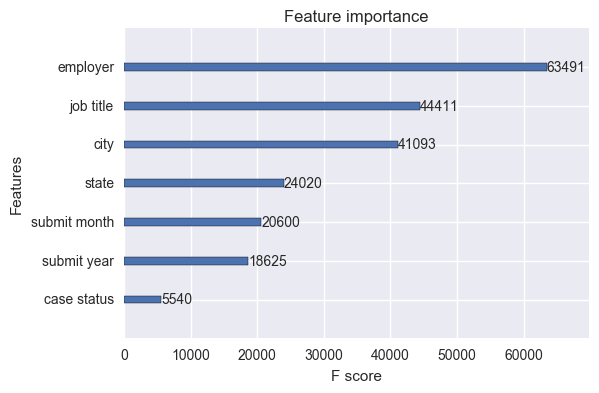

```python
xgb.plot_importance(clf)
```

## Let's predict some potential salaries!

```python
predict_dict = {
    'employer':     ['Google Inc', 'Georgia Institute of Technology','Ove Arup & Partners PC'],
    'job title':    ['Data Scientist', 'Assistant Professor', 'Mechanical Engineer'],
    'state':        ['NY', 'GA', 'NY'],
    'city':         ['New York', 'Atlanta', 'New York'],
    'case status':  ['CERTIFIED', 'CERTIFIED', 'CERTIFIED'],
    'submit year':  [2018, 2018, 2018],
    'submit month': [2, 2, 2]
}
```

```python
def preprocess_new_data(dict,cols_to_transf,future_data_column_order):
    predict_df = pd.DataFrame.from_dict(predict_dict)
    predict_df_transf = predict_df[cols_to_transf]
    predict_df_non_transf = predict_df.drop(cols_to_transf, axis=1)

    for col in predict_df_transf.columns:
        predict_df_transf[col] = predict_df_transf[col].str.upper()

    predict_df = pd.concat([predict_df_transf, predict_df_non_transf], axis=1, join='outer')

    predict_df = encode_future_data(predict_df,cols_to_transf)

    predict_df = predict_df[future_data_column_order]

    return predict_df
```

```python
predict_df = preprocess_new_data(predict_dict, cols_to_transf,future_data_column_order)
```

```python
d_new_data = xgb.DMatrix(predict_df)
```

```python
new_predictions = clf.predict(d_new_data)
```

```python
for i, title in enumerate(predict_dict['job title']):
    print('Your predicted salary as ' + title.title() + ' at ' + predict_dict['employer'][i] +
          ' in ' + predict_dict['city'][i] + ' is ' + '${:,.0f}'.format(int(np.expm1(new_predictions[i]))))
```

```
Your predicted salary as Data Scientist at Google Inc in New York is $145,813
Your predicted salary as Assistant Professor at Georgia Institute of Technology in Atlanta is $110,971
Your predicted salary as Mechanical Engineer at Ove Arup & Partners PC in New York is $81,567
```